# Effects of COP1 Deletion in Microglia in Vivo

Doroteja Vujinovic & Tanya Deniz Toluay

3/20/2021

# Summary of the Experimental Data

Scientists have been studying the involvement of dysregulated microglia in Alzheimer’s disease pathogenesis for the last decade. But the precise mechanisms controlling pathogenic programs of microglia gene expression is very complex and hard to understand.

Scientists know that the transcription factor (TF) c/EBPß is highly expressed in microglia and is known to regulate the expression of pro-inflammatory genes. It is known that in Alzheimer’s disease, c/EBPß is upregulated. It is unclear how TF are tightly regulated because the alterations in its levels are not reflected in the transcript. So the scientists concluded that TF is primarily regulated post-translationally.

In this [data](https://www.ncbi.nlm.nih.gov/geo/query/acc.cgi?acc=GSE145445), scientists want to show that the ubiquitin ligase Cop1 functions as a “brake” on microglial activation. It achieves this by targeting C/EBPß for ubiquitination and subsequent proteasomal mediated degradation. When Cop1 is absent, C/EBPß protein accumulates. It leads to the engagement of a potent pro-inflammatory and ApoE gene-expression program. As evidence, neurotoxicity in microglia-neuronal co-cultures increases.

Antibody blocking studies revealed that the neurotoxicity was almost entirely attributable to complement. Unexpectedly, the loss of a single allele of C/EBPß rescued the pro-inflammatory phenotype underscoring a significant gene dosage effect. They also found that Cop1 deletion accelerated a mouse model of tau-mediated neurodegeneration where elevated ApoE plays a deleterious role. These results identify c/EBPß as a potential therapeutic target for inflammation-driven neurodegeneration.

# Dataset

```r
# Importing the Dataset
GEOid<-"GSE145445"
getGEOSuppFiles(GEOid)
files<-list.files(GEOid,full.names = TRUE);
untar(files[[1]],list = T)
untar(files[[1]],exdir=GEOid)
files<-list.files(GEOid,full.names = TRUE);
gse2<-getGEO(GEOid,GSEMatrix =TRUE)[[1]]
se2= as(gse2, "SummarizedExperiment")
metadata(se2)[[1]]

# Reading the Files
issplit<-map(files, str_split, pattern="\\.", n=2)
unique(sapply(issplit,function(x){x[[1]][[2]]}))
tsvfiles <- list.files(path=GEOid, pattern = '.gz$', ignore.case = TRUE, full.names = TRUE)
tsvlist <- map(tsvfiles, read.table, sep = "\t", header=TRUE)
names(tsvlist)<-tsvfiles
tsvlist%>%map(head,n=10)

# Creating a Single Dataframe
tsvlist%>%map(function(x){x[,"count"]})->listofcols
listofcols%>%map(head, n=3)
df2<-as.data.frame(listofcols)
df2%>%head
colnames(df2)<-colData(se2)[[1]]
rownames(df2)<-tsvlist[[1]][,1]
df2%>%head()
rownames(se2@colData)<-colnames(df2)

# Our Groups
se2@colData$characteristics_ch1.2
se2@colData$characteristics_ch1.2<-factor(str_replace_all(se2@colData$characteristics_ch1.2, "[^A-Za-z0-9_]", "."))

## Creating a Big Dataset
dds2fresh <- DESeqDataSetFromMatrix(countData = df2,
                                    colData = se2@colData,
                                    design = ~ characteristics_ch1.2)
```

```r
knitr::kable(df2%>%head)
```

|  | SAM24335243 Brain LoxP | SAM24335246 Brain LoxP | SAM24335239 Brain WT | SAM24335244 Brain LoxP | SAM24335240 Brain WT | SAM24335245 Brain LoxP | SAM24335242 Brain WT | SAM24335241 Brain WT |
| --- | --- | --- | --- | --- | --- | --- | --- | --- |
| 100009600 | 4 | 7 | 1 | 1 | 2 | 0 | 2 | 3 |
| 100009609 | 0 | 0 | 0 | 0 | 0 | 0 | 0 | 0 |
| 100009614 | 0 | 0 | 0 | 0 | 0 | 0 | 0 | 0 |
| 100009664 | 0 | 1 | 7 | 5 | 9 | 3 | 2 | 3 |
| 100012 | 0 | 0 | 0 | 0 | 0 | 0 | 0 | 0 |
| 100017 | 494 | 872 | 1480 | 1083 | 1172 | 1066 | 1551 | 761 |

## Transformation

The VST is much faster to compute and is less sensitive to high count outliers than the rlog. The rlog tends to work well on small datasets (n < 30), potentially outperforming the VST when there is a wide range of sequencing depth across samples (an order of magnitude difference).

Before filtering the number of rows in the dataset:

```r
dds <- dds2fresh
nrow(dds)
```

```
[1] 36528
```

After the filtering:

```r
keep <- rowSums(counts(dds)) > 1
dds <- dds[keep,]
nrow(dds)
```

```
[1] 22929
```

### VST

```r
vsd <- vst(dds, blind = FALSE)
knitr::kable(head(assay(vsd), 3))
```

|  | SAM24335243 Brain LoxP | SAM24335246 Brain LoxP | SAM24335239 Brain WT | SAM24335244 Brain LoxP | SAM24335240 Brain WT | SAM24335245 Brain LoxP | SAM24335242 Brain WT | SAM24335241 Brain WT |
| --- | --- | --- | --- | --- | --- | --- | --- | --- |
| 100009600 | 7.612315 | 7.622167 | 7.425385 | 7.435139 | 7.477150 | 7.326535 | 7.479867 | 7.533676 |
| 100009664 | 7.326535 | 7.438441 | 7.587761 | 7.569152 | 7.645532 | 7.525751 | 7.479867 | 7.533676 |
| 100017 | 10.073466 | 10.156081 | 10.470192 | 10.329297 | 10.374718 | 10.442704 | 10.742619 | 10.153824 |

### Rlog

```r
rld <- rlog(dds, blind = FALSE)
knitr::kable(head(assay(rld), 3))
```

|  | SAM24335243 Brain LoxP | SAM24335246 Brain LoxP | SAM24335239 Brain WT | SAM24335244 Brain LoxP | SAM24335240 Brain WT | SAM24335245 Brain LoxP | SAM24335242 Brain WT | SAM24335241 Brain WT |
| --- | --- | --- | --- | --- | --- | --- | --- | --- |
| 100009600 | 1.434186 | 1.441857 | 1.369856 | 1.372221 | 1.382602 | 1.361209 | 1.383426 | 1.401507 |
| 100009664 | 1.708810 | 1.718054 | 1.769347 | 1.760588 | 1.798470 | 1.743206 | 1.728187 | 1.746126 |
| 100017 | 9.703836 | 9.782419 | 10.082061 | 9.948733 | 9.991875 | 10.055963 | 10.334583 | 9.780513 |

### Visualization of the Transformation

To show the effect of the transformation, in the figure on the right, we plot the first sample against the second, first simply using the log2 function (after adding 1, to avoid taking the log of zero), and then using the VST and rlog-transformed values. For the log2 approach, we need to first estimate size factors to account for sequencing depth, and then specify the function as normalized. Sequencing depth correction is done automatically for the vst and rlog.

We use the log2 transform of normalized counts (left), the VST (middle), and the rlog (right). While the rlog is on roughly the same scale as the log2 counts, the VST has a upward shift for the smaller values. It is the differences between samples (deviation from y=x in these scatterplots) which will contribute to the distance calculations and the PCA plot.

We can see how genes with low counts (bottom left-hand corner) seem to be excessively variable on the ordinary logarithmic scale, while the VST and rlog compress differences for the low count genes for which the data provide little information about differential expression.

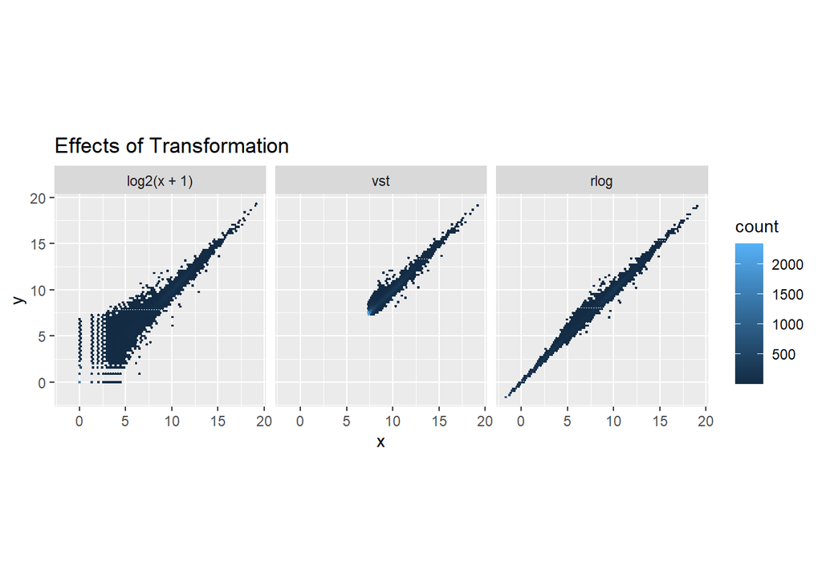

```r
dds2 <- estimateSizeFactors(dds)
df <- bind_rows(
  as.data.frame(log2(counts(dds2, normalized=TRUE)[, 1:2]+1)) %>%
    mutate(transformation = "log2(x + 1)"),
  as.data.frame(assay(vsd)[, 1:2]) %>% mutate(transformation = "vst"),
  as.data.frame(assay(rld)[, 1:2]) %>% mutate(transformation = "rlog"))
colnames(df)[1:2] <- c("x", "y")
lvls <- c("log2(x + 1)", "vst", "rlog")
df$transformation <- factor(df$transformation, levels=lvls)
ggplot(df, aes(x = x, y = y)) + geom_hex(bins = 80) +
  coord_fixed() + facet_grid( . ~ transformation) + ggtitle("Effects of Transformation")
```

## Sample Distancing

A useful first step in an RNA-seq analysis is often to assess the overall similarity between samples. We calculated the Euclidean distance between our samples. We use the data from VST transformation to ensure we have a roughly equal contribution from all genes. Heatmap is a great way to visualise the sample distancing, as it can be seen in the figure on the left.

Another way to visualize sample-to-sample distances is a principal components analysis (PCA). In this ordination method, the data points are projected onto the 2D plane such that they spread out in the two directions that explain most of the differences. The x-axis is the direction that separates the data points the most. The values of the samples in this direction are written PC1. The y-axis is a direction (it must be orthogonal to the first direction) that separates the data the second most. The values of the samples in this direction are written PC2. The percent of the total variance that is contained in the direction is printed in the axis label. Note that these percentages do not add to 100%, because more dimensions contain the remaining variance, although each of these remaining dimensions will explain less than the two that we see.

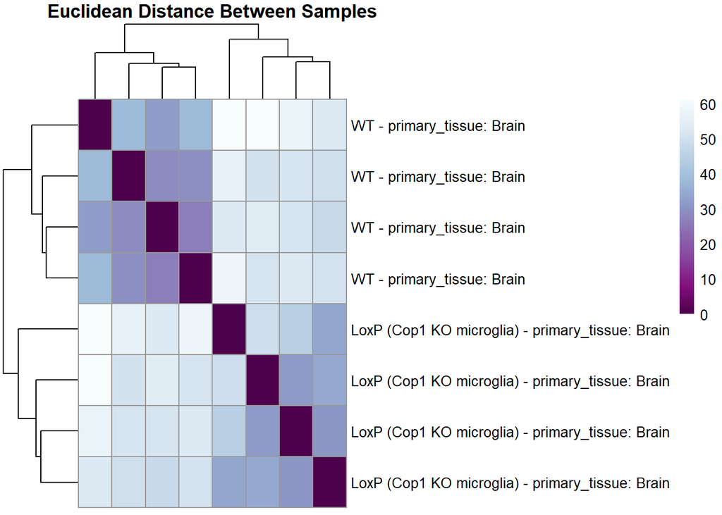

```r
sampleDists <- dist(t(assay(vsd)))

sampleDistMatrix <- as.matrix( sampleDists )
rownames(sampleDistMatrix) <-  paste( vsd$genotype.ch1,vsd$characteristics_ch1.1, sep = " - " )
colnames(sampleDistMatrix) <- NULL
colors <- colorRampPalette( rev(brewer.pal(9, "BuPu")) )(255)

pheatmap(sampleDistMatrix,
         clustering_distance_rows = sampleDists,
         clustering_distance_cols = sampleDists,
         col = colors, main = "Euclidean Distance Between Samples")
```

### Heatmap

We can see in the heatmap provided on the right that there is a behaviour of grouping between the two groups that represent the “WT-primary tissue from the brain” and the “LoxP-primary tissue from the brain”.

Lighter colour squares indicating the high distance between different groups and the purple colour squares indicating the low distance between the members belong to the same group.

Another plot, very similar to the PCA plot, can be made using the multidimensional scaling (MDS) function in base R. Multidimensional scaling (MDS) is a means of visualizing the level of similarity of individual cases of a dataset.

MDS is used to translate “information about the pairwise ‘distances’ among a set of n objects or individuals” into a configuration of n points mapped into an abstract Cartesian space.MDS refers to a set of related ordination techniques used in information visualization, in particular, to display the information contained in a distance matrix. It is a form of non-linear dimensionality reduction.

This is useful when we don’t have a matrix of data, but only a matrix of distances. Here we compute the MDS for the distances calculated from the VST data and plot these in the figure on the left.

We can still see the grouping pattern as in the heatmap, in both PCA and MDS plots. Two groups are clustering on the opposite sides of the x-axis. The pink colour is used for representing the group LoxP, and the blue colour is used for WT.

### PCA Plot

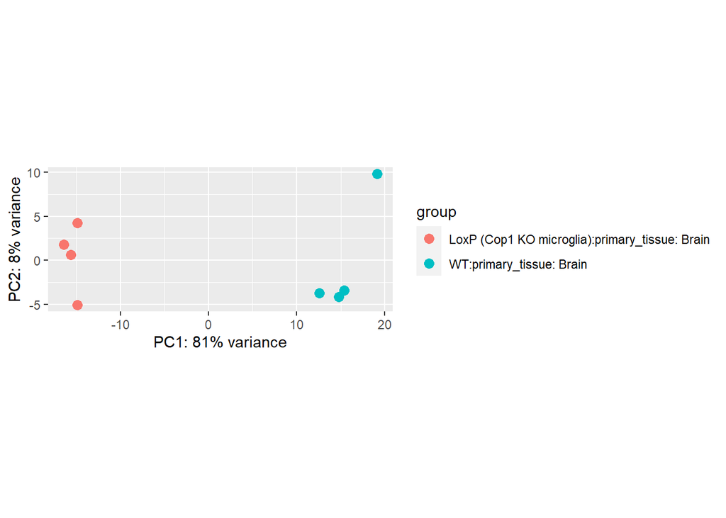

```r
plotPCA(vsd, intgroup = c("genotype.ch1","characteristics_ch1.1"))
```

### MDS Plot

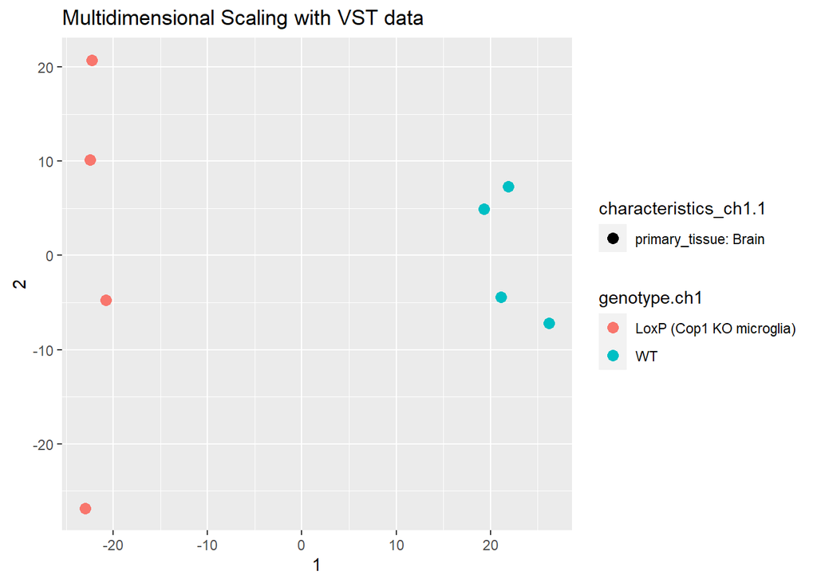

```r
mds <- as.data.frame(colData(vsd))  %>%
  cbind(cmdscale(sampleDistMatrix))
ggplot(mds, aes(x = `1`, y = `2`, color = genotype.ch1, shape = characteristics_ch1.1)) +
  geom_point(size = 3) + coord_fixed() + ggtitle("Multidimensional Scaling with VST data")
```

# Differential Expression Analysis

## Results Table

### Summary of the Results

```r
dds <- DESeq(dds)
res <- results(dds)
res<-results(dds, contrast=c("characteristics_ch1.2", "genotype..WT", "genotype..LoxP..Cop1.KO.microglia."))
#mcols(res, use.names = TRUE)
summary(res)
```

```
out of 22929 with nonzero total read count
adjusted p-value < 0.1
LFC > 0 (up)       : 1895, 8.3%
LFC < 0 (down)     : 2108, 9.2%
outliers [1]       : 85, 0.37%
low counts [2]     : 6217, 27%
(mean count < 5)
[1] see 'cooksCutoff' argument of ?results
[2] see 'independentFiltering' argument of ?results
```

### Filtering the Results

Using R functions, we can lower the false discovery rate threshold. If we use the threshold as 0.05, the results can be seen as in the table on the left.

If we want to raise the log2 fold change threshold, so that we test for genes that show more substantial changes due to treatment, we simply supply a value on the log2 scale. For example, by specifying lfcThreshold = 1, we test for genes that show significant effects of treatment on gene counts more than doubling or less than halving. The results can be seen on the table on the right.

#### Threshold as 0.05

```r
res.05 <- results(dds, alpha = 0.05)
knitr::kable(table(res.05$padj < 0.05))
```

| Var1 | Freq |
| --- | --- |
| FALSE | 13004 |
| TRUE | 3187 |

#### Log2 Fold Change Threshold

```r
resLFC1 <- results(dds, lfcThreshold=1)
knitr::kable(table(resLFC1$padj < 0.1))
```

| Var1 | Freq |
| --- | --- |
| FALSE | 17613 |
| TRUE | 341 |

## Multiple Testing

In high-throughput biology, we are careful to not use the p values directly as evidence against the null, but to correct for multiple testing. There are 5000 genes with a p value below 0.05 among the 22844 genes for which the test succeeded in reporting a p value.

If we consider a fraction of 10% false positives acceptable, we can consider all genes with an adjusted p value below 10% = 0.1 as significant: 4003

We subset the results table to these genes and then sort it by the log2 fold change estimate to get the significant genes with the strongest down-regulation:

```r
resSig <- subset(res, padj < 0.1)
knitr::kable(head(resSig[ order(resSig$log2FoldChange), ]))
```

|  | baseMean | log2FoldChange | lfcSE | stat | pvalue | padj |
| --- | --- | --- | --- | --- | --- | --- |
| 12765 | 806.79227 | -9.498619 | 0.4882944 | -19.452648 | 0.0e+00 | 0.000000 |
| 20210 | 155.70840 | -8.850383 | 0.8630087 | -10.255264 | 0.0e+00 | 0.000000 |
| 102638802 | 19.15824 | -7.845493 | 1.1846932 | -6.622383 | 0.0e+00 | 0.000000 |
| 442827 | 28.82182 | -7.709666 | 1.1506203 | -6.700443 | 0.0e+00 | 0.000000 |
| 245126 | 64.02213 | -7.137305 | 0.8027738 | -8.890804 | 0.0e+00 | 0.000000 |
| 102639575 | 13.47265 | -6.615132 | 1.5625476 | -4.233555 | 2.3e-05 | 0.000296 |

…and with the strongest up-regulation:

```r
knitr::kable(head(resSig[ order(resSig$log2FoldChange, decreasing = TRUE), ]))
```

|  | baseMean | log2FoldChange | lfcSE | stat | pvalue | padj |
| --- | --- | --- | --- | --- | --- | --- |
| 435391 | 8.268618 | 6.368503 | 1.3451677 | 4.734356 | 0.0000022 | 0.0000355 |
| 74424 | 7.856320 | 6.290082 | 1.3137694 | 4.787813 | 0.0000017 | 0.0000279 |
| 102636796 | 7.029435 | 6.130513 | 1.4479567 | 4.233906 | 0.0000230 | 0.0002958 |
| 76206 | 1568.337173 | 5.186700 | 0.2124596 | 24.412640 | 0.0000000 | 0.0000000 |
| 18416 | 7.757102 | 4.820536 | 1.4356667 | 3.357698 | 0.0007859 | 0.0065405 |
| 20352 | 304.391785 | 4.731326 | 0.6952697 | 6.805023 | 0.0000000 | 0.0000000 |

# Plot Results

## Counts Plot

A quick way to visualize the counts for a particular gene is to use the plotCounts function in R.

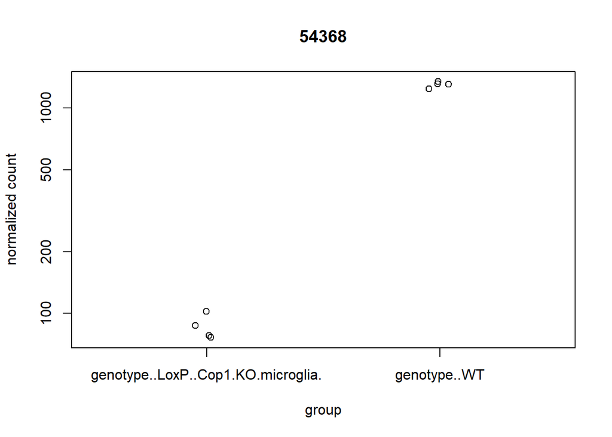

```r
topGene <- rownames(res)[which.min(res$padj)]
plotCounts(dds, gene = topGene, intgroup=c("characteristics_ch1.2"))
```

## MA-plot

An MA-plot provides a useful overview for the distribution of the estimated coefficients in the model, e.g. the comparisons of interest, across all genes. On the y-axis, the “M” stands for “minus” – subtraction of log values is equivalent to the log of the ratio – and on the x-axis, the “A” stands for “average”. You may hear this plot also referred to as a mean-difference plot, or a Bland-Altman plot.

We wanted to shrink the noisy log2 fold changes and how this difference effects the data, so we applied statistical moderation. Therefore we included two different plots; with statistical moderation and without statistical moderation. We can also detect the individual points in our graph.

The grey dots represent non significant genes for our dataset. We can see how different our samples are in terms of read counts. The data points converge to zero at Y-axis because log (A/A) is zero.

Another useful diagnostic plot is the histogram of the p values. This plot is best formed by excluding genes with very small counts, which otherwise generate spikes in the histogram.

### With Statistical Moderation

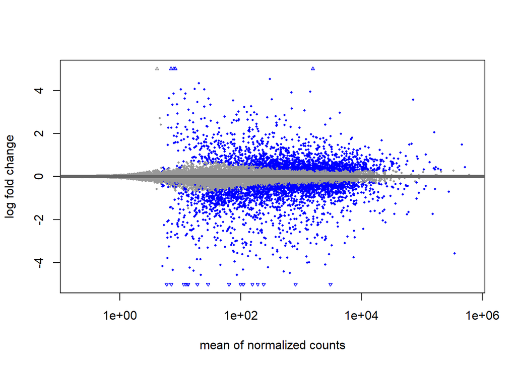

```r
library("apeglm")
#resultsNames(dds)
res <- lfcShrink(dds, coef="characteristics_ch1.2_genotype..WT_vs_genotype..LoxP..Cop1.KO.microglia.", type="apeglm")
plotMA(res, ylim = c(-5, 5))
```

### MA Plot With Labeling Individual Points

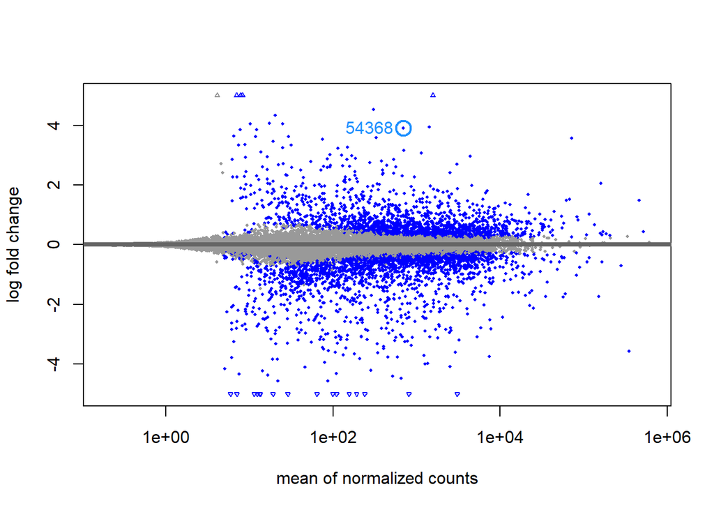

```r
plotMA(res, ylim = c(-5,5))
topGene <- rownames(res)[which.min(res$padj)]
with(res[topGene, ], {
  points(baseMean, log2FoldChange, col="dodgerblue", cex=2, lwd=2)
  text(baseMean, log2FoldChange, topGene, pos=2, col="dodgerblue")
})
```

### Without Statistical Moderation

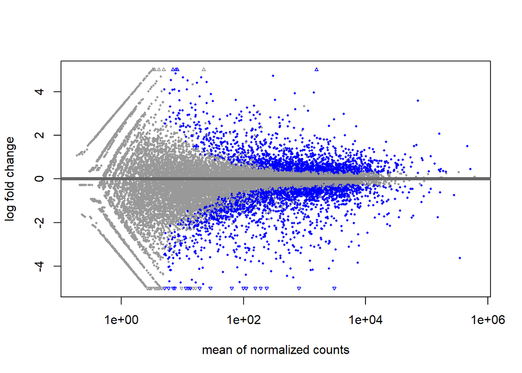

```r
res.noshr <- results(dds, name="characteristics_ch1.2_genotype..WT_vs_genotype..LoxP..Cop1.KO.microglia.")
plotMA(res.noshr, ylim = c(-5, 5))
```

### Histogram

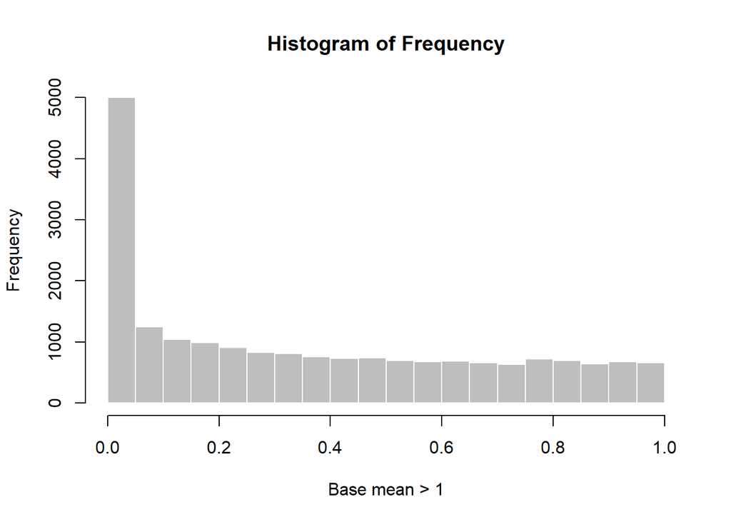

```r
hist(res$pvalue[res$baseMean > 1], breaks = 0:20/20,
     col = "grey", border = "white", main= "Histogram of Frequency", xlab = "Base mean > 1")
```

## Gene Clustering

+11816 Apoe apolipoprotein E: involved in the transport of lipoproteins in the blood. Different alleles of this gene have been associated with either increased risk or a protective effect for Alzheimer’s disease in human patients.

+13058 Cytochrome b-245, beta polypeptide: encodes the heavy chain component of a heterodimeric transmembrane ion transporter composed of both a heavy and a light chain. This transporter mediates the transfer of electrons from nicotinamide adenine dinucleotide phosphate (NADPH) to oxygen to generate superoxide. This reaction is important in the innate immune response to pathogens.

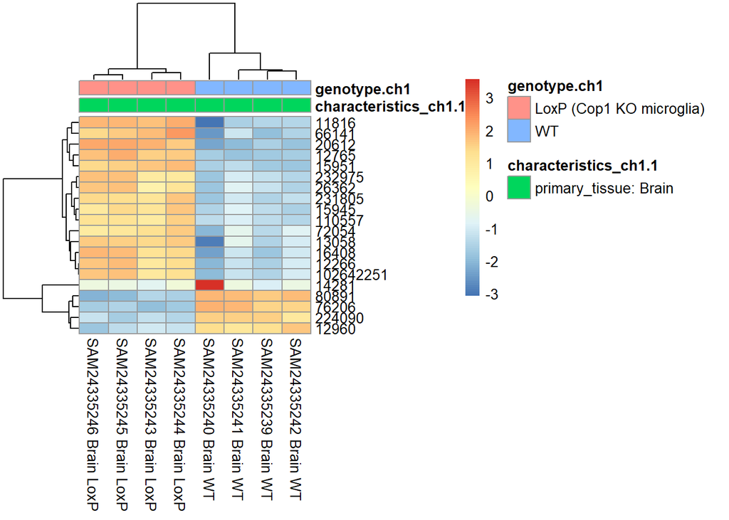

```r
library("genefilter")
topVarGenes <- head(order(rowVars(assay(vsd)), decreasing = TRUE), 20)

mat  <- assay(vsd)[ topVarGenes, ]
mat  <- mat - rowMeans(mat)
anno <- as.data.frame(colData(vsd)[, c("characteristics_ch1.1","genotype.ch1")])
pheatmap(mat, annotation_col = anno)
```

In the sample distance heatmap made previously, the dendrogram at the side shows us a hierarchical clustering of the samples. Such clustering can also be performed for the genes. Since the clustering is only relevant for genes that carry a signal, one usually would only cluster a subset of the most highly variable genes.

The heatmap becomes more interesting if we do not look at absolute expression strength but rather at the amount by which each gene deviates in a specific sample from the gene’s average across all samples. Hence, we center each genes’ values across samples and plot a heatmap.

# Annotating results

This is the organism annotation package (“org”) for Mus muculus (“Mm”), organized as an AnnotationDbi database package (“db”), using Entrez Gene IDs (“eg”) as primary key. We can see all the available key types in this database:

```r
columns(org.Mm.eg.db)
```

```
 [1] "ACCNUM"       "ALIAS"        "ENSEMBL"      "ENSEMBLPROT"  "ENSEMBLTRANS"
 [6] "ENTREZID"     "ENZYME"       "EVIDENCE"     "EVIDENCEALL"  "GENENAME"
[11] "GO"           "GOALL"        "IPI"          "MGI"          "ONTOLOGY"
[16] "ONTOLOGYALL"  "PATH"         "PFAM"         "PMID"         "PROSITE"
[21] "REFSEQ"       "SYMBOL"       "UNIGENE"      "UNIPROT"
```

We used the the mapIds function to add individual columns to our results table in order to add the information we want.This way we added the desired external gene IDs to our result.

```r
ens.str <- substr(rownames(res), 1, 15)
res$symbol <- mapIds(org.Mm.eg.db,
                     keys=ens.str,
                     column="SYMBOL",
                     keytype="ENTREZID",
                     multiVals="first")


resOrdered <- res[order(res$pvalue),]
knitr::kable(head(resOrdered))
```

|  | baseMean | log2FoldChange | lfcSE | pvalue | padj | symbol |
| --- | --- | --- | --- | --- | --- | --- |
| 54368 | 693.4972 | 3.903072 | 0.1479056 | 0 | 0 | Gp9 |
| 76206 | 1568.3372 | 5.169555 | 0.2123168 | 0 | 0 | Gpr165 |
| 24099 | 2579.9708 | -2.877028 | 0.1238819 | 0 | 0 | Tnfsf13b |
| 80891 | 71429.4588 | 3.564520 | 0.1571153 | 0 | 0 | Fcrls |
| 15951 | 2517.8771 | -4.082040 | 0.1831499 | 0 | 0 | Ifi204 |
| 236312 | 645.4238 | -3.021344 | 0.1456599 | 0 | 0 | Ifi209 |

```r
dfannotation2<-mapIds(x=org.Mm.eg.db,
                      keys = rownames(counts(dds)),
                      column = "SYMBOL",
                      keytype = "ENTREZID",
                      multiVals = "first")


duplicates<-dfannotation2[duplicated(dfannotation2)]
```

```r
#  Volcano plot
df2<-as.data.frame(counts(dds))
colData<-colData(dds)
metadata<-metadata(dds)
database<-org.Mm.eg.db


#rownames(df2)%>%head
symbols <- select(database, keys = rownames(df2),
                  column = c("SYMBOL"), keytype = "ENTREZID")

df2%>%mutate(RowNames=rownames(.))%>%right_join(symbols,by=c("RowNames"="ENTREZID"))%>%filter(!is.na(SYMBOL))->dfjoined
knitr::kable(dfjoined%>%head)
```

| SAM24335243 Brain LoxP | SAM24335246 Brain LoxP | SAM24335239 Brain WT | SAM24335244 Brain LoxP | SAM24335240 Brain WT | SAM24335245 Brain LoxP | SAM24335242 Brain WT | SAM24335241 Brain WT | RowNames | SYMBOL |
| --- | --- | --- | --- | --- | --- | --- | --- | --- | --- |
| 4 | 7 | 1 | 1 | 2 | 0 | 2 | 3 | 100009600 | Zglp1 |
| 0 | 1 | 7 | 5 | 9 | 3 | 2 | 3 | 100009664 | F630206G17Rik |
| 494 | 872 | 1480 | 1083 | 1172 | 1066 | 1551 | 761 | 100017 | Ldlrap1 |
| 457 | 451 | 415 | 467 | 326 | 406 | 230 | 262 | 100019 | Mdn1 |
| 5 | 16 | 18 | 3 | 13 | 7 | 4 | 22 | 100033459 | Ifi208 |
| 128 | 334 | 181 | 200 | 9 | 173 | 176 | 106 | 100034251 | Wfdc17 |

## Volcano Plot

Volcano Plot is great for to identify changes in large data sets composed of replicate data. It combines a measure of statistical significance from a statistical test with the magnitude of the change, enabling quick visual identification of those data-points like genes. This way we can plot significance versus fold-change on the y and x axes, respectively.

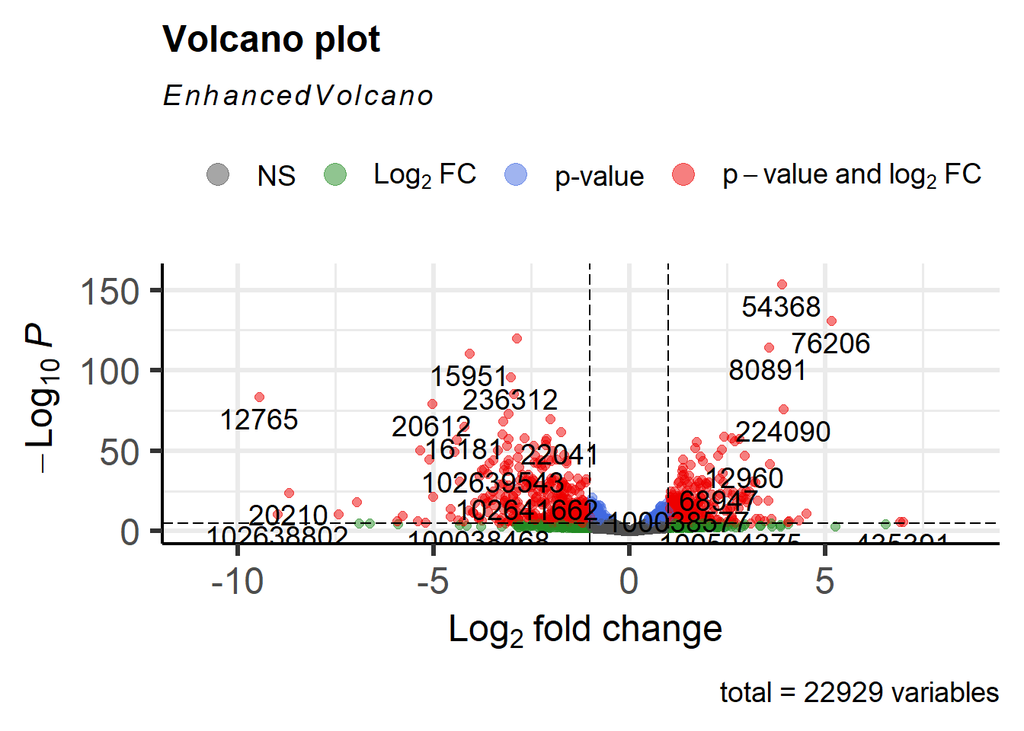

```r
dfjoined%>%select_if(is.numeric)->dfannotated
rownames(dfannotated)<-dfjoined[,"SYMBOL"]


dds <- DESeq(dds, betaPrior=FALSE)

dds$characteristics_ch1 <- as.factor(dds$characteristics_ch1)
dds$characteristics_ch1.1 <- as.factor(dds$characteristics_ch1.1)
dds$characteristics_ch1.2 <- as.factor(dds$characteristics_ch1.2)



EnhancedVolcano(res,
                lab = rownames(res),
                x = 'log2FoldChange',
                y = 'pvalue')
```

## Bar Plot of Expressed Characteristics

Bar plot is the most widely used method to visualize enriched terms. It depicts the enrichment scores and gene count or ratio as bar height and color.

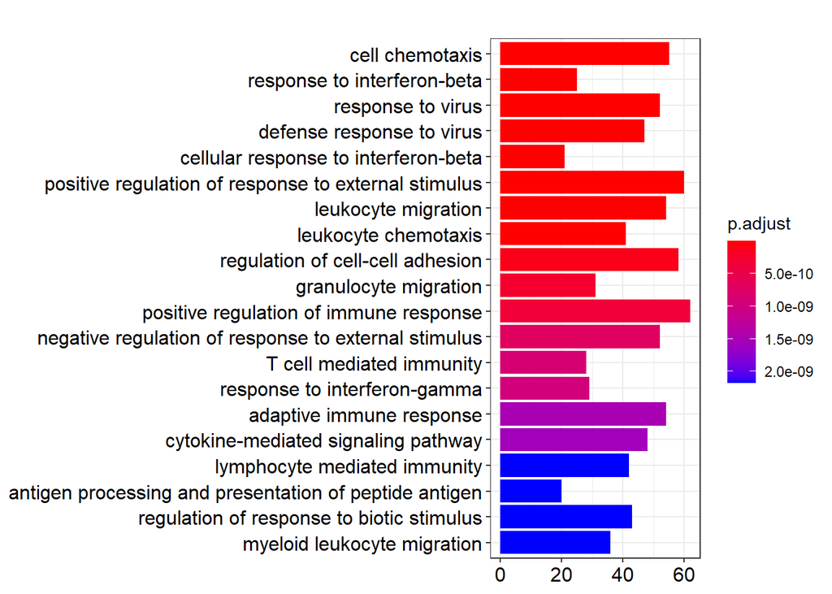

```r
pkgs<-c("DESeq2","SummarizedExperiment","GEOquery","biomaRt","tidyverse","stringr","pheatmap","RColorBrewer","hexbin","clusterProfiler","org.Hs.eg.db","org.Mm.eg.db")
invisible(sapply(pkgs,library, character.only = TRUE))



res<-res[!is.na(res$padj),]
SigExpGenes<-res[(res$padj < 0.05) & (abs(res$log2FoldChange)>1),]


ggo1 <- groupGO(gene     = rownames(SigExpGenes),
                OrgDb    = org.Mm.eg.db,
                keyType = "ENTREZID",
                ont      = "BP",
                level    = 1,
                readable = F)


ggo2 <- groupGO(gene     = rownames(SigExpGenes),
                                 OrgDb    = org.Mm.eg.db,
                                 keyType = "ENTREZID",
                                 ont      = "BP",
                                  level    = 2,
                                 readable = F)



ego <- enrichGO(gene          = rownames(SigExpGenes),
                universe      = rownames(counts(dds)),
                OrgDb         = org.Mm.eg.db,
                keyType       = 'ENTREZID',
                ont           = "BP",
                pAdjustMethod = "BH",
                pvalueCutoff  = 0.05,
                qvalueCutoff  = 0.05,
                readable      = F)
dfego<-as.data.frame(ego[,-8])


barplot(ego, showCategory = 20)
```

## Gene Concept Network Plot

The barplot only displayed most significant enriched terms, while users may want to know which genes are involved in these significant terms. The cnetplot depicts the linkages of genes and biological concepts as a network.

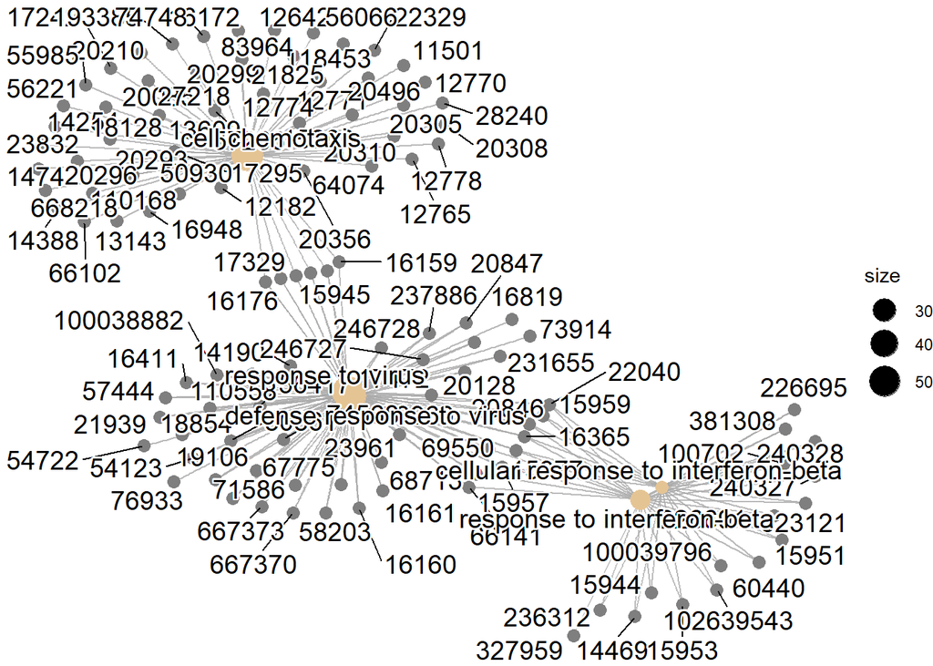

```r
cnetplot(ego, categorySize = "pvalue", foldChange = rownames(SigExpGenes))
```

# Gene Enrichment Analysis

## Significantly Expressed Genes

We can create a dataset of significantly expressed genes in order to understand the data better. It is important to understand which genes are expressed because the gene expression is the process by which the information encoded in a gene is used to direct the assembly of a protein molecule.

```r
SigExpGenes$ENTREZID<-AnnotationDbi::mapIds(x=database,
                       keys = rownames(SigExpGenes),
                       column = "SYMBOL",
                       keytype = "ENTREZID",
                       multiVals = "first")
knitr::kable(head(SigExpGenes))
```

|  | baseMean | log2FoldChange | lfcSE | pvalue | padj | symbol | ENTREZID |
| --- | --- | --- | --- | --- | --- | --- | --- |
| 100034675 | 13.427827 | 1.843466 | 0.8658017 | 0.001451 | 0.0109854 | Gm11335 | Gm11335 |
| 100038468 | 18.884249 | -3.842220 | 0.7618092 | 0.000000 | 0.0000007 | Gm10684 | Gm10684 |
| 100038577 | 4302.591760 | 1.243139 | 0.1390839 | 0.000000 | 0.0000000 | Gm10790 | Gm10790 |
| 100038608 | 6.316134 | -2.052653 | 1.6089279 | 0.004361 | 0.0269653 | Gm10389 | Gm10389 |
| 100038882 | 440.942852 | -2.184034 | 0.2136863 | 0.000000 | 0.0000000 | Isg15 | Isg15 |
| 100039795 | 452.563764 | -1.767652 | 0.2673362 | 0.000000 | 0.0000000 | Ildr2 | Ildr2 |

```r
kk <- enrichKEGG(gene         = rownames(SigExpGenes),
                 organism     = 'mmu',
                 pAdjustMethod = "BH",
                 qvalueCutoff = 0.2,
                 pvalueCutoff = 0.05)
kkres<-as.data.frame(kk@result)
#knitr::kable(head(kkres))
```

We can also see the associated pathways for our dataset and the small description about them. As expected, since the transcription factor (TF) c/EBPß is highly expressed in microglia and is known to regulate the expression of pro-inflammatory genes, we can see a lot of other disease related pathways as well.

```r
significantkkres<-kkres[kkres$pvalue<kk@pvalueCutoff & kkres$p.adjust<kk@pvalueCutoff & kkres$qvalue < kk@qvalueCutoff,2,drop=F]
significantkkres
```

```
                                                           Description
mmu04514                                       Cell adhesion molecules
mmu04060                        Cytokine-cytokine receptor interaction
mmu05330                                           Allograft rejection
mmu04061 Viral protein interaction with cytokine and cytokine receptor
mmu04940                                      Type I diabetes mellitus
mmu05169                                  Epstein-Barr virus infection
mmu05332                                     Graft-versus-host disease
mmu04145                                                     Phagosome
mmu05171                                Coronavirus disease - COVID-19
mmu05416                                             Viral myocarditis
mmu05320                                    Autoimmune thyroid disease
mmu05164                                                   Influenza A
mmu04612                           Antigen processing and presentation
mmu05163                               Human cytomegalovirus infection
mmu05144                                                       Malaria
mmu05168                              Herpes simplex virus 1 infection
mmu05167               Kaposi sarcoma-associated herpesvirus infection
mmu04062                                   Chemokine signaling pathway
mmu05162                                                       Measles
mmu05140                                                 Leishmaniasis
mmu05165                                Human papillomavirus infection
mmu04621                           NOD-like receptor signaling pathway
mmu05166                       Human T-cell leukemia virus 1 infection
mmu05323                                          Rheumatoid arthritis
mmu04620                          Toll-like receptor signaling pathway
mmu04933          AGE-RAGE signaling pathway in diabetic complications
mmu05170                      Human immunodeficiency virus 1 infection
mmu04672                  Intestinal immune network for IgA production
mmu04668                                         TNF signaling pathway
mmu05203                                          Viral carcinogenesis
mmu05205                                       Proteoglycans in cancer
mmu05321                                    Inflammatory bowel disease
mmu05160                                                   Hepatitis C
mmu04625                      C-type lectin receptor signaling pathway
mmu04512                                      ECM-receptor interaction
mmu04640                                    Hematopoietic cell lineage
mmu04979                                        Cholesterol metabolism
mmu04218                                           Cellular senescence
mmu04658                              Th1 and Th2 cell differentiation
mmu05142                                                Chagas disease
mmu04657                                       IL-17 signaling pathway
mmu05146                                                    Amoebiasis
mmu05417                                     Lipid and atherosclerosis
mmu05145                                                 Toxoplasmosis
mmu04510                                                Focal adhesion
mmu04622                         RIG-I-like receptor signaling pathway
mmu04380                                    Osteoclast differentiation
mmu05418                        Fluid shear stress and atherosclerosis
mmu05152                                                  Tuberculosis
mmu04623                                 Cytosolic DNA-sensing pathway
mmu04064                                  NF-kappa B signaling pathway
mmu05143                                       African trypanosomiasis
mmu04216                                                   Ferroptosis
```

```r
links<-sapply(rownames(head(kk)),function(x){browseKEGG(kk, x)})

GEOID<-"GSE145445"
setwd(GEOid)
geneList<-SigExpGenes$log2FoldChange
names(geneList)<-rownames(SigExpGenes)
```

## KEGG Pathways

[ClusterProfiler](https://bioconductor.org/packages/release/bioc/html/clusterProfiler.html) users can also use pathview from the pathview to visualize KEGG pathway.

The following example illustrates how to visualize the “mmu04514” pathway, which was enriched in our previous analysis.

We can see the significantly expressed genes represented by their colours on the pathway map.

```r
mmu04514 <- pathview(gene.data  = geneList,
                     pathway.id = "mmu04514",
                     species    = "mmu",
                     limit      = list(gene=max(abs(geneList)), cpd=1))
```

[figure not shown]

The tables of Ensembl data is downloadable with the BioMart data-mining tool so we are using BioMart to extract the data we need.

The used datasets can be seen on the table given, with the Ensembl version.

```r
setwd("..")
mkk <- enrichMKEGG(gene         = rownames(SigExpGenes),
                 organism     = 'mmu',
                 pAdjustMethod = "BH",
                 qvalueCutoff = 0.2,
                 pvalueCutoff = 0.05)
#knitr::kable(head(mkk))
mkkres<-as.data.frame(mkk@result)
listMarts()
```

```
               biomart                version
1 ENSEMBL_MART_ENSEMBL      Ensembl Genes 103
2   ENSEMBL_MART_MOUSE      Mouse strains 103
3     ENSEMBL_MART_SNP  Ensembl Variation 103
4 ENSEMBL_MART_FUNCGEN Ensembl Regulation 103
```

```r
ensembl <- useMart("ensembl")
datasets <- listDatasets(ensembl)

datasets[grep("[mM]ouse",datasets$description),]
```

```
                     dataset                                      description
95      mcaroli_gene_ensembl             Ryukyu mouse genes (CAROLI_EIJ_v1.1)
106    mmurinus_gene_ensembl                     Mouse Lemur genes (Mmur_3.0)
107   mmusculus_gene_ensembl                             Mouse genes (GRCm39)
110     mpahari_gene_ensembl              Shrew mouse genes (PAHARI_EIJ_v1.1)
112 mspicilegus_gene_ensembl                     Steppe mouse genes (MUSP714)
113    mspretus_gene_ensembl              Algerian mouse genes (SPRET_EiJ_v1)
150   pmbairdii_gene_ensembl Northern American deer mouse genes (HU_Pman_2.1)
            version
95  CAROLI_EIJ_v1.1
106        Mmur_3.0
107          GRCm39
110 PAHARI_EIJ_v1.1
112         MUSP714
113    SPRET_EiJ_v1
150     HU_Pman_2.1
```

```r
ensembl = useDataset("mmusculus_gene_ensembl",mart=ensembl)
filters = listFilters(ensembl)

annotation1<-AnnotationDbi::select(x=database,
                      keys = rownames(counts(dds)),
                      column = c("SYMBOL", "ENTREZID"),
                      keytype = "ENTREZID",
                      multiVals = "first")


annotation2<-getBM(attributes=c("ensembl_gene_id","description","chromosome_name", 'entrezgene_id',"uniprot_gn_symbol","mgi_symbol"),
                   filters = "entrezgene_id",
                  values =  annotation1$ENTREZID,
                  mart = ensembl)

annotation2$entrezgene_id<-as.character(annotation2$entrezgene_id)
annotation3<-annotation1%>%inner_join(annotation2,by=c("ENTREZID" = "entrezgene_id"))
```

## Vizualization

We can see the dataset as given for each group:

```r
knitr::kable(counts(dds)%>%head)
```

|  | SAM24335243 Brain LoxP | SAM24335246 Brain LoxP | SAM24335239 Brain WT | SAM24335244 Brain LoxP | SAM24335240 Brain WT | SAM24335245 Brain LoxP | SAM24335242 Brain WT | SAM24335241 Brain WT |
| --- | --- | --- | --- | --- | --- | --- | --- | --- |
| 100009600 | 4 | 7 | 1 | 1 | 2 | 0 | 2 | 3 |
| 100009664 | 0 | 1 | 7 | 5 | 9 | 3 | 2 | 3 |
| 100017 | 494 | 872 | 1480 | 1083 | 1172 | 1066 | 1551 | 761 |
| 100019 | 457 | 451 | 415 | 467 | 326 | 406 | 230 | 262 |
| 100033459 | 5 | 16 | 18 | 3 | 13 | 7 | 4 | 22 |
| 100034251 | 128 | 334 | 181 | 200 | 9 | 173 | 176 | 106 |

Now to create an understandable visualization we can use boxplots per group. First it can be seen on the left, boxplot 1, the plot is created by the boxplot function in R. In order to see any differences for the depth normalization, we also created the boxplot on the right side, for normalized counts.

### Read Counts Only

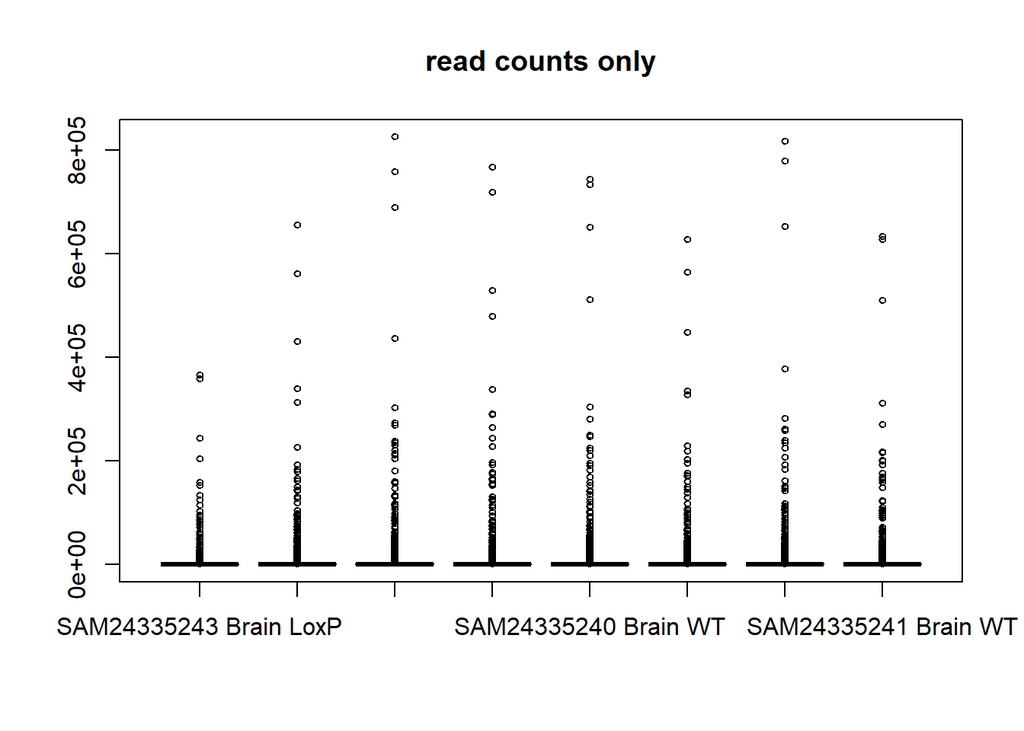

```r
boxplot(counts(dds), main = "read counts only", cex = .6)
```

### Non-normalized

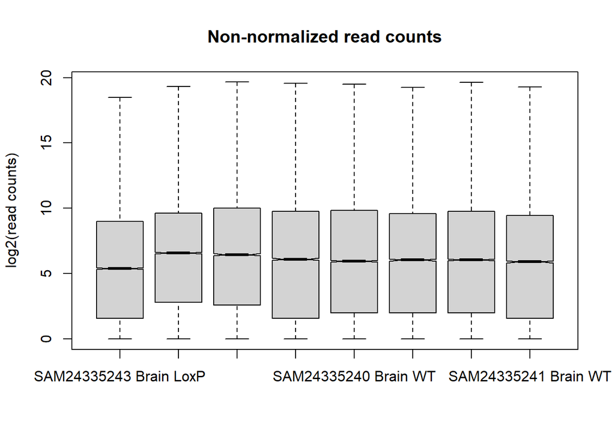

```r
boxplot(log2(counts(dds)+1), notch=TRUE,
main = "Non-normalized read counts",
ylab="log2(read counts)", cex = .6)
```

### Normalized

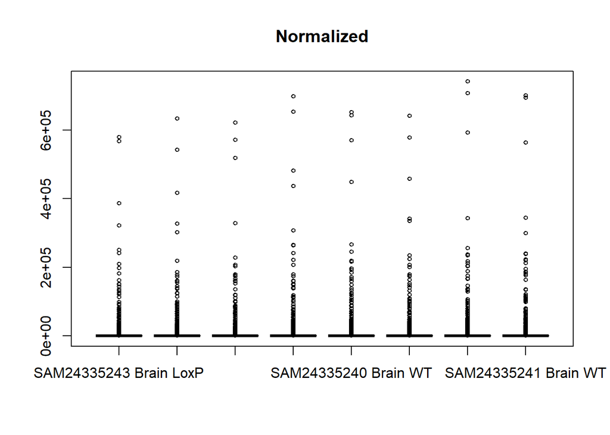

```r
counts.sf_normalized <- counts(dds, normalized=TRUE)

boxplot(counts.sf_normalized, main = "Normalized", cex = .6)
```

### Normalized

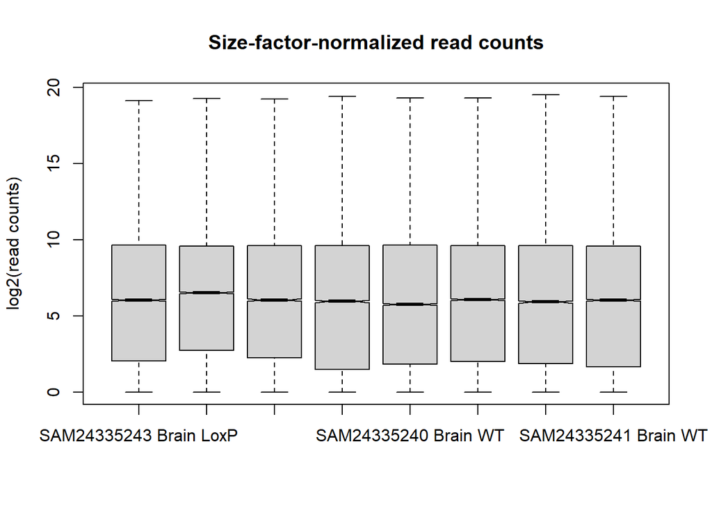

```r
boxplot(log2(counts(dds, normalize= TRUE) +1), notch=TRUE,
main = "Size-factor-normalized read counts",
ylab="log2(read counts)", cex = .6)
```

On the left it can be seen the first boxplot, the plot is created by ggplot function. We can see the mean value and the outliers for each group. The plot is based on the assay implementation on our dataset.

On the right we can see the second boxplot, we are using the vst function in R to implement variance stabilizing transformation in our dataset.

### VSD Normalization

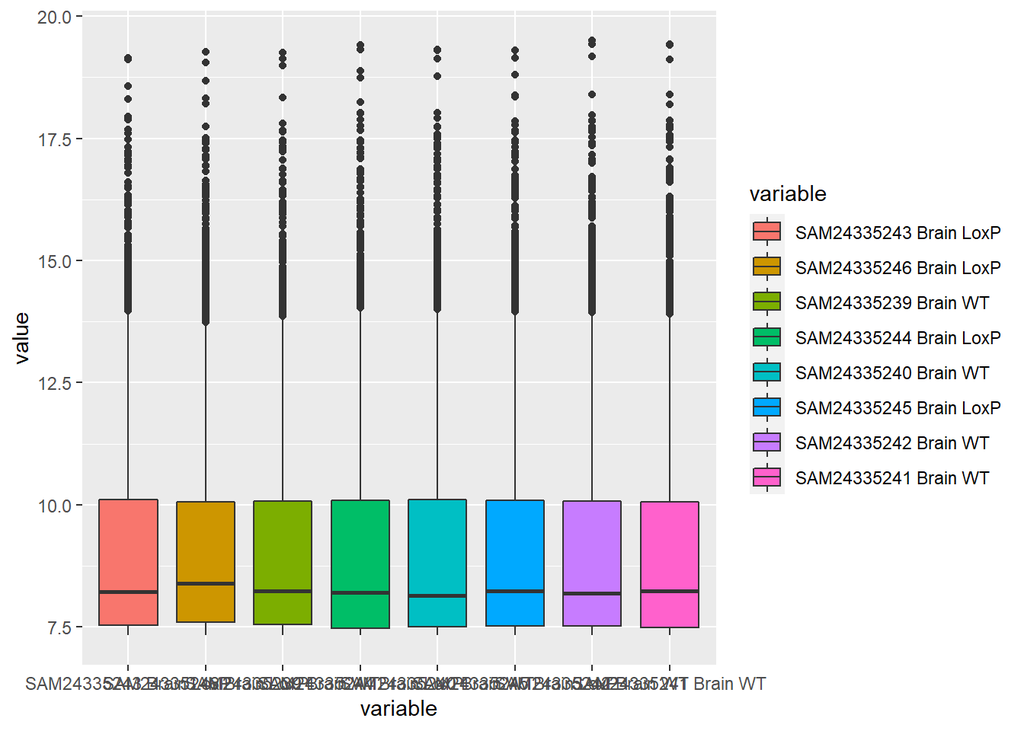

```r
df2<-as.data.frame(assay(vsd))
ggplot(data = melt(df2), aes(x=variable, y=value)) + geom_boxplot(aes(fill=variable))
```

### VSD Normalization via VST

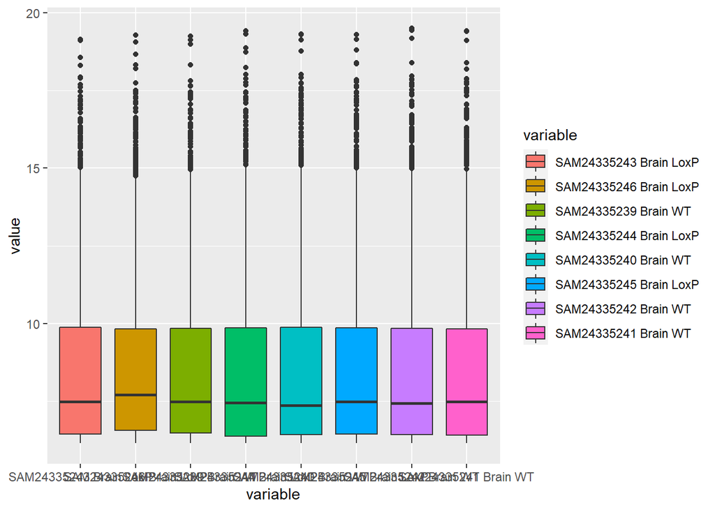

```r
vsd <- vst(dds)
df2<-as.data.frame(assay(vsd))
ggplot(data = melt(df2), aes(x=variable, y=value)) + geom_boxplot(aes(fill=variable))
```

[figure not shown]

```r
plotDispEsts(dds)
```

### Dispersion Plot

We can also use dispersion plot in our data to understand per-gene dispersion estimates together with the fitted mean-dispersion relationship. We can draw the plots by the function plotDispEsts in R.

### Rlog Normalization

We can see the first entries in our dataset as given below:

```r
rld <- rlog(dds)
knitr::kable(assay(rld)%>%head)
```

|  | SAM24335243 Brain LoxP | SAM24335246 Brain LoxP | SAM24335239 Brain WT | SAM24335244 Brain LoxP | SAM24335240 Brain WT | SAM24335245 Brain LoxP | SAM24335242 Brain WT | SAM24335241 Brain WT |
| --- | --- | --- | --- | --- | --- | --- | --- | --- |
| 100009600 | 1.440461 | 1.450658 | 1.354095 | 1.357323 | 1.371409 | 1.342328 | 1.372526 | 1.396904 |
| 100009664 | 1.690403 | 1.702910 | 1.771851 | 1.760174 | 1.810316 | 1.736890 | 1.716638 | 1.740810 |
| 100017 | 9.738278 | 9.806479 | 10.066892 | 9.950575 | 9.988143 | 10.044134 | 10.289302 | 9.804752 |
| 100019 | 9.126938 | 8.667960 | 8.383961 | 8.646023 | 8.308775 | 8.624730 | 8.062827 | 8.321182 |
| 100033459 | 3.344220 | 3.450428 | 3.425502 | 3.258095 | 3.393773 | 3.330748 | 3.273235 | 3.559987 |
| 100034251 | 7.414085 | 7.806260 | 7.122363 | 7.336619 | 5.973919 | 7.313685 | 7.237475 | 7.016908 |

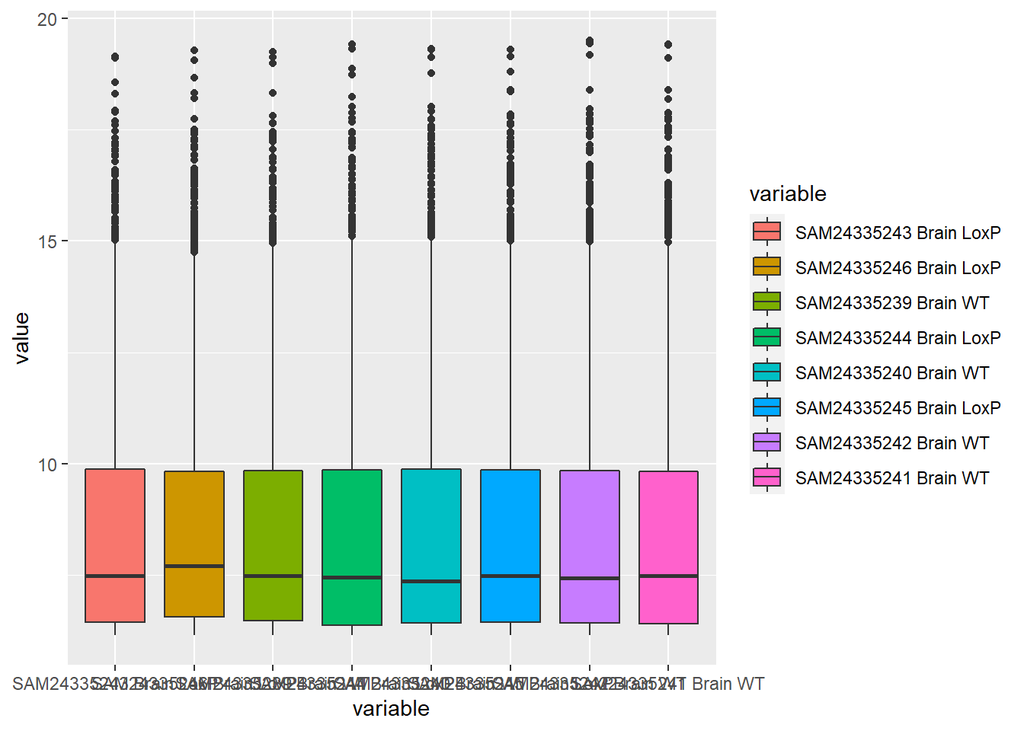

```r
df3<-as.data.frame(assay(vsd))
ggplot(data = melt(df3), aes(x=variable, y=value)) + geom_boxplot(aes(fill=variable))
```

The mean values differ between the groups but not by a huge difference, rather by wiggling.

There are outliers in each group, and the maximum value is similar nearly in all of them by minor differences.